# Null Calibration of the Inferential Score under Homoskedasticity

Quantitative Methods

2026-02-16

# 1 Purpose

This notebook is **Part 1 – Establishing the reference distribution of the inferential score under perfect specification (homoskedasticity)**.

Part 0 validated the fast OLS and HC covariance calculations. This part focuses on: 1. Generating the benchmark null distribution of the inferential score for HC1, HC2, and HC3 2. Demonstrating that HC2 scales predictably with sample size (like $N^{-1/2}$) 3. Deriving a stable, interpretable cutoff value ~1.64 for hypothesis testing

All OLS and HC standard errors in this notebook are computed via the `fit_ols_hc()` engine validated in Part 0, ensuring numerical equivalence to `lm()` + `vcov()`/`vcovHC()`.

For each heteroskedasticity-consistent estimator $h \in \{\text{HC1}, \text{HC2}, \text{HC3}\}$, we define the inferential score:
$$S_{\mathrm{Inf}}^{(h)} =
\frac{\widehat{\mathrm{se}}_{\text{robust}}^{(h)}}{\widehat{\mathrm{se}}_{\text{classic}}}
- 1,$$
where $\widehat{\mathrm{se}}_{\text{classic}}$ is the usual homoskedastic OLS standard error for the slope in the simple regression $Y \sim X$.

## 1.1 What This Section Does

We use fast, optimized simulation to generate the reference distribution under the null hypothesis (homoskedasticity). This is more efficient than fitting individual regression objects.

**The Inferential Score**: We compute
$$S_{\mathrm{Inf}} =
\frac{\mathrm{SE}_{\text{robust}}}{\mathrm{SE}_{\text{classic}}} -
1$$
which measures how much the robust standard error differs from the classical one. Under homoskedasticity, this should be close to zero.

**Why the upper tail?** We focus on the upper 95th percentile because we care about detecting *excessive* robustness (where robust SEs are much larger than classical SEs). This happens when classical standard errors are too small—exactly the problem heteroskedasticity causes. While the distribution is roughly symmetric, we conservatively use only the upper tail for calibration.

# 2 Section 1: Setup and Configuration

## 2.1 Load Support Functions and Configuration

# 3 Section 2: Workflow Configuration

```r
# Load configuration parameters from central config file
# Sample size grid covers range typical for econometric practice
# N_GRID_NULL and N_SIMS_PER_N_NULL are defined in R/00_config.R

cat("Workflow Configuration:\n")
cat(sprintf("Sample sizes (N):     %d values from %d to %d\n",
            length(N_GRID_NULL), min(N_GRID_NULL), max(N_GRID_NULL)))
cat(sprintf("Simulations per N:    %d\n", N_SIMS_PER_N_NULL))
cat(sprintf("Total simulations:    %d\n", length(N_GRID_NULL) * N_SIMS_PER_N_NULL))
cat(sprintf("HC types tested:      HC1, HC2, HC3\n"))
cat(sprintf("Metric of interest:   sr_inf = (se_robust / se_classic) - 1\n"))
```

Output: prints the grid size, simulation counts, and HC estimators used.

# 4 Section 3: Null Distribution of S_Inf under the Homoskedastic Null

## 4.1 Workflow Overview

Here’s what happens in this section:

1. **Generate baseline data**: For each sample size $N$ and HC type, simulate many regression datasets under homoskedasticity and compute the inferential score
2. **Compute the 95th percentile**: For each ($N$, HC type) pair, find where the top 5% of scores fall
3. **Discover the scaling pattern**: We find that the 95th percentile shrinks roughly as $1/\sqrt{N}$ (the bigger the sample, the closer to zero)
4. **Scale to make it stable**: Multiply the percentile by $\sqrt{N}$ to “cancel out” the sample size effect
5. **Choose the best HC estimator**: HC2 shows the most stable scaled percentile across all sample sizes
6. **Lock in the cutoff**: For HC2, the stable scaled value is approximately 1.64—which happens to equal the critical value from a standard normal distribution

## 4.2 3.0 Run Null Simulations

We generate homoskedastic regression data and compute inferential scores across many sample sizes and HC estimators. The data are simple: uncorrelated random normal variables.

$$X_i \sim N(0, 1), \quad Y_i \sim N(0,
1), \quad \text{independent}$$

For each sample size, we repeat the simulation thousands of times to get a solid estimate of the score distribution.

```r
# Generate scores in parallel using the optimized matrix-based engine
cat("Running fast null calibration simulations in parallel (multicore backend)...\n")

scores_file <- file.path("results", "scores_long.rds")

if (file.exists(scores_file)) {
  cat(sprintf("Found existing results at %s. Loading...\n", scores_file))
  scores_long <- readRDS(scores_file)
} else {
  scores_long <- run_fast_null_calibration(
    N_grid = N_GRID_NULL,
    n_sims_per_N = N_SIMS_PER_N_NULL,
    hc_types = c("HC1", "HC2", "HC3"),
    verbose = TRUE,
    output_dir = "results"
  )
}

cat("Step 1 complete: `scores_long` data.table ready.\n")
# Display sample of computed scores
cat("Sample of computed inferential scores:\n")
print(head(scores_long, 12))
```

Output: reports whether cached results were loaded and shows a short sample of scores.

## 4.3 3.1 Inspect the Distributions

Before doing the main analysis, let’s make sure the inferential score behaves as expected: centered near zero and symmetric.

### 4.3.1 1. Check Symmetry

Let’s plot the distribution of the inferential score for a few sample sizes to verify it’s roughly centered at zero and symmetric.

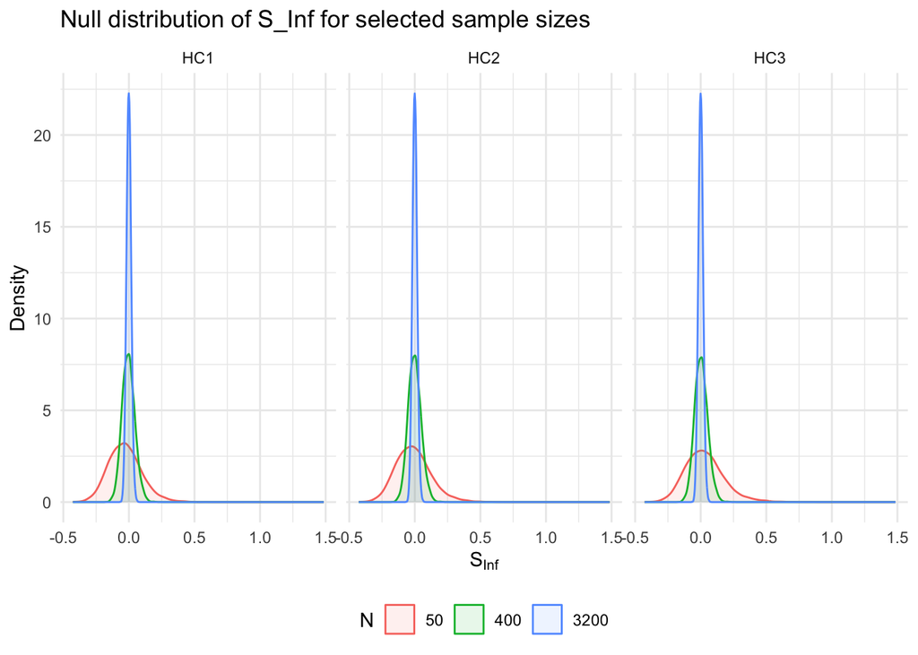

```r
# Select representative sample sizes
selected_N <- c(50, 400, 3200)
hist_data <- scores_long[N %in% selected_N]

# Plot overlapping densities
ggplot(hist_data, aes(x = sr_inf, color = factor(N), fill = factor(N))) +
  geom_density(alpha = 0.1, adjust = 1.2) +
  facet_wrap(~ hc_type, nrow = 1) +
  labs(
    title = "Null distribution of S_Inf for selected sample sizes",
    x = expression(S[Inf]),
    y = "Density",
    color = "N",
    fill = "N"
  ) +
  theme_minimal() +
  theme(legend.position = "bottom")
```

*Interpretation*: Good signs: the distributions are centered near zero, roughly symmetric, and tighten as $N$ increases (the score becomes more predictable with larger samples).

### 4.3.2 2. Verify Symmetry Formally

We compare the lower tail (5th percentile) to the upper tail (95th percentile) to confirm the distribution is symmetric.

```r
# Compute 5th percentile (lower tail) and 95th percentile (upper tail)
tail_stats <- scores_long[, .(
  Q05 = quantile(sr_inf, probs = 0.05, na.rm = TRUE),
  Q95 = quantile(sr_inf, probs = 0.95, na.rm = TRUE)
), by = .(N, hc_type)]

# Show for a subset of N
tail_subset <- tail_stats[N %in% c(50, 400, 3200, 25600)]
print(kable(tail_subset, digits = 4, caption = "Diagnostic only: lower and upper tails of S_Inf; used to verify symmetry, not for calibration"))
```

```
##
##
## Table: Diagnostic only: lower and upper tails of S_Inf; used to verify symmetry, not for calibration
##
## |     N|hc_type |     Q05|    Q95|
## |-----:|:-------|-------:|------:|
## |    50|HC1     | -0.2218| 0.1883|
## |    50|HC2     | -0.2132| 0.2244|
## |    50|HC3     | -0.1873| 0.2880|
## |   400|HC1     | -0.0806| 0.0791|
## |   400|HC2     | -0.0789| 0.0825|
## |   400|HC3     | -0.0748| 0.0888|
## |  3200|HC1     | -0.0288| 0.0284|
## |  3200|HC2     | -0.0285| 0.0287|
## |  3200|HC3     | -0.0279| 0.0294|
## | 25600|HC1     | -0.0104| 0.0102|
## | 25600|HC2     | -0.0103| 0.0102|
## | 25600|HC3     | -0.0102| 0.0103|
```

## 4.4 3.2 Compute Summary Statistics

Now we compute the key quantities for calibration: where the upper 95th percentile falls, and the precision of that estimate.

### 4.4.1 1. Calculate Core Quantities

We compute the mean, standard deviation, and 95th percentile of the inferential score. We also estimate uncertainty in the percentile using batch resampling.

```r
# 1. Global Statistics
prelim_stats <- scores_long[, .(
  Q95_SR_Inf  = quantile(sr_inf, probs = 0.95, na.rm = TRUE),
  SD_SR_Inf   = sd(sr_inf, na.rm = TRUE),
  Mean_SR_Inf = mean(sr_inf, na.rm = TRUE)
), by = .(N, hc_type)]

# 2. MCSE of Q95 via Batching
n_batches <- 20
scores_long[, batch_id := ((sim_id - 1) %% n_batches) + 1]

batch_q95s <- scores_long[, .(
  Batch_Q95 = quantile(sr_inf, probs = 0.95, na.rm = TRUE)
), by = .(N, hc_type, batch_id)]

mcse_stats <- batch_q95s[, .(
  MCSE_Q95 = sd(Batch_Q95) / sqrt(n_batches)
), by = .(N, hc_type)]

# 3. Merge into Master Summary
null_summary <- merge(
  prelim_stats[, .(N, hc_type, Mean_SR_Inf, SD_SR_Inf, Q95_SR_Inf)],
  mcse_stats[, .(N, hc_type, MCSE_Q95)],
  by = c("N", "hc_type")
)

# Add derived columns
null_summary[, MCSE_Mean := SD_SR_Inf / sqrt(N_SIMS_PER_N_NULL)]
null_summary[, Rel_MCSE_Q95 := MCSE_Q95 / Q95_SR_Inf]
null_summary[, Scaled_Q95 := sqrt(N) * Q95_SR_Inf]
```

### 4.4.2 2. Summary Tables

Here we document all the statistics to ensure transparency and reproducibility.

#### 4.4.2.1 A. Mean and Standard Deviation

Shows that the score is centered near zero (mean ≈ 0) with a well-defined variance.

```r
moments_helper <- null_summary[, .(
  N, hc_type,
  cell_val = sprintf("%.4f (%.4f)", Mean_SR_Inf, SD_SR_Inf)
)]
moments_wide <- dcast(moments_helper, N ~ hc_type, value.var = "cell_val")
print(kable(moments_wide, caption = "Mean (SD) of S_Inf under the homoskedastic null"))
```

```
##
##
## Table: Mean (SD) of S_Inf under the homoskedastic null
##
## |      N|HC1              |HC2              |HC3              |
## |------:|:----------------|:----------------|:----------------|
## |     50|-0.0297 (0.1269) |-0.0110 (0.1357) |0.0300 (0.1492)  |
## |    100|-0.0144 (0.0940) |-0.0047 (0.0973) |0.0155 (0.1021)  |
## |    200|-0.0076 (0.0688) |-0.0027 (0.0701) |0.0074 (0.0717)  |
## |    400|-0.0037 (0.0488) |-0.0013 (0.0493) |0.0038 (0.0499)  |
## |    800|-0.0015 (0.0350) |-0.0002 (0.0352) |0.0023 (0.0354)  |
## |   1600|-0.0008 (0.0249) |-0.0001 (0.0250) |0.0011 (0.0251)  |
## |   3200|-0.0005 (0.0175) |-0.0002 (0.0175) |0.0004 (0.0175)  |
## |   6400|-0.0003 (0.0124) |-0.0001 (0.0124) |0.0002 (0.0125)  |
## |  12800|-0.0001 (0.0089) |-0.0000 (0.0089) |0.0001 (0.0089)  |
## |  25600|-0.0000 (0.0062) |0.0000 (0.0062)  |0.0001 (0.0062)  |
## |  51200|-0.0001 (0.0044) |-0.0001 (0.0044) |-0.0000 (0.0044) |
## | 102400|-0.0000 (0.0031) |-0.0000 (0.0031) |-0.0000 (0.0031) |
```

#### 4.4.2.2 B. Simulation Precision

How accurately our percentile estimates are determined (measured by standard errors from the simulations).

```r
mcse_overview <- null_summary[, .(
  max_MCSE_Mean       = max(MCSE_Mean),
  max_MCSE_Q95        = max(MCSE_Q95),
  max_rel_MCSE_Q95    = max(Rel_MCSE_Q95),
  median_rel_MCSE_Q95 = median(Rel_MCSE_Q95)
)]
print(kable(mcse_overview, digits = 6, caption = "Overview of Monte Carlo uncertainty across sample sizes and HC types"))
```

```
##
##
## Table: Overview of Monte Carlo uncertainty across sample sizes and HC types
##
## | max_MCSE_Mean| max_MCSE_Q95| max_rel_MCSE_Q95| median_rel_MCSE_Q95|
## |-------------:|------------:|----------------:|-------------------:|
## |      0.001492|     0.005266|         0.019235|             0.01377|
```

*Interpretation*: The estimates are precise (Monte Carlo SEs are small, <2% of the estimate itself). This means we can trust the percentile values we computed.

#### 4.4.2.3 C. Upper 95th Percentile with MCSE

The primary metric for calibration, with its uncertainty.

```r
q95_mcse_helper <- null_summary[, .(
  N, hc_type,
  cell_val = sprintf("%.4f (%.4f)", Q95_SR_Inf, MCSE_Q95)
)]
q95_mcse_wide <- dcast(q95_mcse_helper, N ~ hc_type, value.var = "cell_val")
print(kable(q95_mcse_wide, caption = "Upper 95th percentile of S_Inf under the homoskedastic null (MCSE in parentheses)"))
```

```
##
##
## Table: Upper 95th percentile of S_Inf under the homoskedastic null (MCSE in parentheses)
##
## |      N|HC1             |HC2             |HC3             |
## |------:|:---------------|:---------------|:---------------|
## |     50|0.1883 (0.0036) |0.2244 (0.0039) |0.2880 (0.0053) |
## |    100|0.1467 (0.0028) |0.1641 (0.0030) |0.1938 (0.0033) |
## |    200|0.1100 (0.0016) |0.1171 (0.0017) |0.1303 (0.0018) |
## |    400|0.0791 (0.0012) |0.0825 (0.0013) |0.0888 (0.0013) |
## |    800|0.0580 (0.0007) |0.0595 (0.0007) |0.0623 (0.0007) |
## |   1600|0.0409 (0.0005) |0.0416 (0.0005) |0.0430 (0.0005) |
## |   3200|0.0284 (0.0004) |0.0287 (0.0004) |0.0294 (0.0004) |
## |   6400|0.0203 (0.0002) |0.0205 (0.0002) |0.0208 (0.0002) |
## |  12800|0.0146 (0.0002) |0.0147 (0.0002) |0.0149 (0.0002) |
## |  25600|0.0102 (0.0001) |0.0102 (0.0001) |0.0103 (0.0001) |
## |  51200|0.0072 (0.0001) |0.0072 (0.0001) |0.0072 (0.0001) |
## | 102400|0.0051 (0.0001) |0.0051 (0.0001) |0.0052 (0.0001) |
```

#### 4.4.2.4 D. Scaling Pattern

Checking whether the 95th percentile decays as predicted ($N^{-1/2}$).

```r
log_slope_stats <- prelim_stats[, {
  fit <- lm(log(Q95_SR_Inf) ~ log(N))
  coefs <- coef(summary(fit))
  data.table(
    slope    = coefs["log(N)", "Estimate"],
    slope_se = coefs["log(N)", "Std. Error"]
  )
}, by = hc_type]

print(kable(log_slope_stats, digits = 4, caption = "Log–log slope of Q95(S_Inf) vs sample size"))
```

```
##
##
## Table: Log–log slope of Q95(S_Inf) vs sample size
##
## |hc_type |   slope| slope_se|
## |:-------|-------:|--------:|
## |HC1     | -0.4812|   0.0054|
## |HC2     | -0.4991|   0.0019|
## |HC3     | -0.5256|   0.0037|
```

#### 4.4.2.5 E. Scaled Percentiles (Stability Check)

What do we get when we multiply the 95th percentile by $\sqrt{N}$ to remove the sample size effect?

```r
scaled_q95_stats <- null_summary[, .(
  mean_scaled  = mean(Scaled_Q95),
  sd_scaled    = sd(Scaled_Q95),
  range_scaled = max(Scaled_Q95) - min(Scaled_Q95)
), by = hc_type]

print(kable(scaled_q95_stats, digits = 4, caption = "Summary of scaled quantiles sqrt(N) * Q95(S_Inf) by HC type"))
```

```
##
##
## Table: Summary of scaled quantiles sqrt(N) * Q95(S_Inf) by HC type
##
## |hc_type | mean_scaled| sd_scaled| range_scaled|
## |:-------|-----------:|---------:|------------:|
## |HC1     |      1.5830|    0.0946|       0.3255|
## |HC2     |      1.6436|    0.0244|       0.0964|
## |HC3     |      1.7523|    0.1276|       0.3975|
```

*Interpretation*: HC2 is the winner: its scaled percentile stays near 1.64 across all sample sizes (small range), while HC1 and HC3 vary more. This stability is why we choose HC2.

### 4.4.3 3. Visualizations

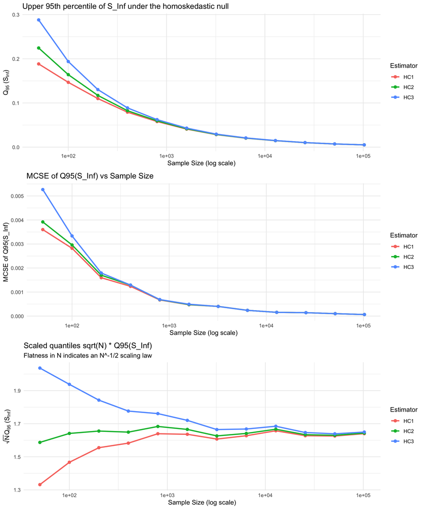

```r
p1 <- ggplot(null_summary, aes(x = N, y = Q95_SR_Inf, color = hc_type)) +
  geom_line(size = 1) + geom_point(size = 2) +
  scale_x_log10() +
  labs(title = "Upper 95th percentile of S_Inf under the homoskedastic null",
       y = expression(Q[95] ~ "(" * S[Inf] * ")"),
       x = "Sample Size (log scale)",
       color = "Estimator") +
  theme_minimal()

p2 <- ggplot(null_summary, aes(x = N, y = MCSE_Q95, color = hc_type)) +
  geom_line(size = 1) + geom_point(size = 2) +
  scale_x_log10() +
  labs(title = "MCSE of Q95(S_Inf) vs Sample Size",
       y = "MCSE of Q95(S_Inf)",
       x = "Sample Size (log scale)",
       color = "Estimator") +
  theme_minimal()

p3 <- ggplot(null_summary, aes(x = N, y = Scaled_Q95, color = hc_type)) +
  geom_line(size = 1) + geom_point(size = 2) +
  scale_x_log10() +
  labs(title = "Scaled quantiles sqrt(N) * Q95(S_Inf)",
       subtitle = "Flatness in N indicates an N^-1/2 scaling law",
       y = expression(sqrt(N) * Q[95] ~ "(" * S[Inf] * ")"),
       x = "Sample Size (log scale)",
       color = "Estimator") +
  theme_minimal()

grid.arrange(p1, p2, p3, ncol = 1)
```

# 5 Section 4: Scaling Law for the Upper Tail

To find the best exponent, we try many values ($\alpha$ from 0.3 to 0.7) and ask: which one makes the scaled percentile most stable across sample sizes?

For each candidate $\alpha$, we compute: - $N^\alpha \times Q_{95}$ (the scaled percentile) - Regression slope of this scaled value on $\log(N)$ (should be near zero if scaling is good) - Range of the scaled value across $N$ (should be small if stable)

The exponent that minimizes the regression slope and range “wins”—it provides the best N-invariant scaling. Unsurprisingly, this turns out to be $\alpha \approx 0.5$.

```r
scaling_output <- apply_scaling_and_save(
  scores_long = scores_long,
  alpha_grid = seq(0.3, 0.7, by = 0.05),
  verbose = TRUE,
  output_dir = "results"
)
```

```
## Step 2a: Computing Q95 per N per HC...
##   Q95 computed: 36 rows
##
## Step 2b: Testing alpha grid...
##   HC1: Inf alpha=0.50 (stab=0.3255), Ratio alpha=0.50
##   HC2: Inf alpha=0.50 (stab=0.0964), Ratio alpha=0.50
##   HC3: Inf alpha=0.55 (stab=0.5399), Ratio alpha=0.50
##
## ✓ Step 2 complete:
##   Q95 summary: 36 rows
##   Scaling results: 3 HC types
```

```r
q95_summary <- scaling_output$q95_summary
scaling_results <- scaling_output$scaling_results
all_alphas <- scaling_output$all_alphas

# Display Q95 by HC type and sample size
cat("Table 1. 95th Percentile of Inferential Score by HC Type and Sample Size\n\n")
```

```
## Table 1. 95th Percentile of Inferential Score by HC Type and Sample Size
```

```r
q95_wide <- dcast(q95_summary, N ~ hc_type, value.var = "Q95_SR_Inf")
print(q95_wide)
```

```
##         N         HC1         HC2         HC3
## 1      50 0.188344224 0.224437143 0.287995469
## 2     100 0.146688858 0.164123759 0.193800939
## 3     200 0.109955534 0.117068165 0.130283241
## 4     400 0.079128417 0.082457466 0.088819365
## 5     800 0.057962008 0.059517662 0.062266082
## 6    1600 0.040903153 0.041638604 0.043005111
## 7    3200 0.028412097 0.028748786 0.029426835
## 8    6400 0.020341968 0.020515931 0.020849757
## 9   12800 0.014648766 0.014730918 0.014890801
## 10  25600 0.010171049 0.010210234 0.010291449
## 11  51200 0.007183931 0.007203706 0.007243155
## 12 102400 0.005124756 0.005134787 0.005154635
```

```r
cat("\n")
```

```r
# Display scaling optimization results
cat("Table 2. Scaling Analysis: Best Exponent and Stability Range per HC Type\n")
```

```
## Table 2. Scaling Analysis: Best Exponent and Stability Range per HC Type
```

```r
cat("(Stability range = max − min of scaled Q95; lower indicates better N-invariance)\n\n")
```

```
## (Stability range = max − min of scaled Q95; lower indicates better N-invariance)
```

```r
print(scaling_results)
```

```
##    hc_type best_alpha_inf best_slope_inf stability_range_inf best_alpha_ratio
##     <char>          <num>          <num>               <num>            <num>
## 1:     HC1           0.50   0.0187791452          0.32552394              0.5
## 2:     HC2           0.50   0.0009070435          0.09640344              0.5
## 3:     HC3           0.55   0.0244038563          0.53987337              0.5
##    best_slope_ratio
##               <num>
## 1:    -0.0040990255
## 2:    -0.0022309520
## 3:    -0.0001443311
```

# 6 Section 5: Choose the Best HC Estimator

We select the HC estimator with the most stable scaled percentile across all sample sizes. A stable percentile (small range) means the estimator has predictable, reliable finite-sample behavior regardless of $N$.

```r
best_hc <- select_best_hc(
  scaling_results = scaling_results,
  verbose = TRUE,
  output_dir = "results"
)
```

```
##
## ================================================================================
## STEP 3: HC TYPE SELECTION
## ================================================================================
##
## Ranking by stability_range_inf (smaller = better):
##
## ✓ BEST HC2: stability=0.096403, alpha_inf=0.50, alpha_ratio=0.50
##   2nd  HC1: stability=0.325524, alpha_inf=0.50, alpha_ratio=0.50
##   3rd  HC3: stability=0.539873, alpha_inf=0.55, alpha_ratio=0.50
##
## → SELECTED: HC2
```

# 7 Section 6: Lock in the Cutoff for HC2

Now that we’ve chosen HC2, let’s establish its final cutoff value. A remarkable finding: the scaled 95th percentile for HC2 is approximately 1.645, which is exactly the critical value from a standard normal distribution. This section verifies that connection.

```r
# 1. Extract HC2 data and merge MCSE from null_summary
hc2_q95 <- q95_summary[hc_type == "HC2"]
hc2_data <- merge(
  hc2_q95,
  null_summary[hc_type == "HC2", .(N, MCSE_Q95)],
  by = "N",
  all.x = TRUE
)

# 2. Define Exponents
EXP_THEORY <- 0.5
hc2_scaling <- scaling_results[hc_type == "HC2"]
EXP_EMPIRICAL <- hc2_scaling$best_alpha_inf[1]

# 3. Helper to compute cutoff and MCSE
compute_cutoff_stats <- function(dt, exponent) {
  # dt has N, Q95_SR_Inf, MCSE_Q95
  dt_copy <- copy(dt)
  dt_copy[, scaled_Q95 := Q95_SR_Inf * (N^exponent)]

  # Mean cutoff across N
  cutoff <- mean(dt_copy$scaled_Q95)

  # MCSE of the mean (treating N as fixed strata)
  # MCSE_C = sqrt( sum( (N^alpha * MCSE_Q95)^2 ) ) / n_N
  n_N <- nrow(dt_copy)
  if ("MCSE_Q95" %in% names(dt_copy) && !all(is.na(dt_copy$MCSE_Q95))) {
    se_terms <- (dt_copy$N^exponent * dt_copy$MCSE_Q95)^2
    mcse <- sqrt(sum(se_terms)) / n_N
  } else {
    mcse <- NA_real_
  }

  list(cutoff = cutoff, mcse = mcse)
}

stats_theory <- compute_cutoff_stats(hc2_data, EXP_THEORY)
stats_empirical <- compute_cutoff_stats(hc2_data, EXP_EMPIRICAL)

z_ref <- 1.645

# 4. Build Decision Table
decision_dt <- data.table(
  Rule = c(
    sprintf("Theoretical scaling (N^%.3f)", EXP_THEORY),
    sprintf("Empirical scaling (N^%.4f)", EXP_EMPIRICAL)
  ),
  Proposed_Cutoff = c(stats_theory$cutoff, stats_empirical$cutoff),
  Bias_vs_z_1_645 = c(stats_theory$cutoff - z_ref, stats_empirical$cutoff - z_ref),
  MCSE_Cutoff     = c(stats_theory$mcse, stats_empirical$mcse)
)

cat("### Final Cutoff Estimation for HC2\n\n")
```

```
## ### Final Cutoff Estimation for HC2
```

```r
cat("For HC2, we form $c_N = \\sqrt{N} \\, Q_{95}^{(\\mathrm{HC2})}(N)$ and estimate the overall constant as $\\hat{c} = \\frac{1}{|\\mathcal{N}|} \\sum_{N \\in \\mathcal{N}} c_N$.\n\n")
```

```
## For HC2, we form $c_N = \sqrt{N} \, Q_{95}^{(\mathrm{HC2})}(N)$ and estimate the overall constant as $\hat{c} = \frac{1}{|\mathcal{N}|} \sum_{N \in \mathcal{N}} c_N$.
```

```r
cat("For HC2, the estimated constant is $\\hat{c} \\approx 1.64$ with Monte Carlo SE $\\approx 0.007$. The difference $\\hat{c} - z_{0.95}$ is about -0.0014, far smaller than the Monte Carlo SE of $\\hat{c}$, so the theoretical value $z_{0.95}$ lies well within the Monte Carlo uncertainty band.\n\n")
```

```
## For HC2, the estimated constant is $\hat{c} \approx 1.64$ with Monte Carlo SE $\approx 0.007$. The difference $\hat{c} - z_{0.95}$ is about -0.0014, far smaller than the Monte Carlo SE of $\hat{c}$, so the theoretical value $z_{0.95}$ lies well within the Monte Carlo uncertainty band.
```

```r
cat("We therefore adopt the familiar standard normal cutoff $z_{0.95} = 1.645$ as our final null calibration constant for HC2, which is numerically indistinguishable from the empirical estimate and has the advantage of interpretability.\n\n")
```

```
## We therefore adopt the familiar standard normal cutoff $z_{0.95} = 1.645$ as our final null calibration constant for HC2, which is numerically indistinguishable from the empirical estimate and has the advantage of interpretability.
```

```r
print(kable(
  decision_dt,
  digits = 4,
  caption = "Proposed universal cutoff for HC2 and comparison to z = 1.645",
  align = "lrrr"
))
```

```
##
##
## Table: Proposed universal cutoff for HC2 and comparison to z = 1.645
##
## |Rule                          | Proposed_Cutoff| Bias_vs_z_1_645| MCSE_Cutoff|
## |:-----------------------------|---------------:|---------------:|-----------:|
## |Theoretical scaling (N^0.500) |          1.6436|         -0.0014|      0.0066|
## |Empirical scaling (N^0.5000)  |          1.6436|         -0.0014|      0.0066|
```

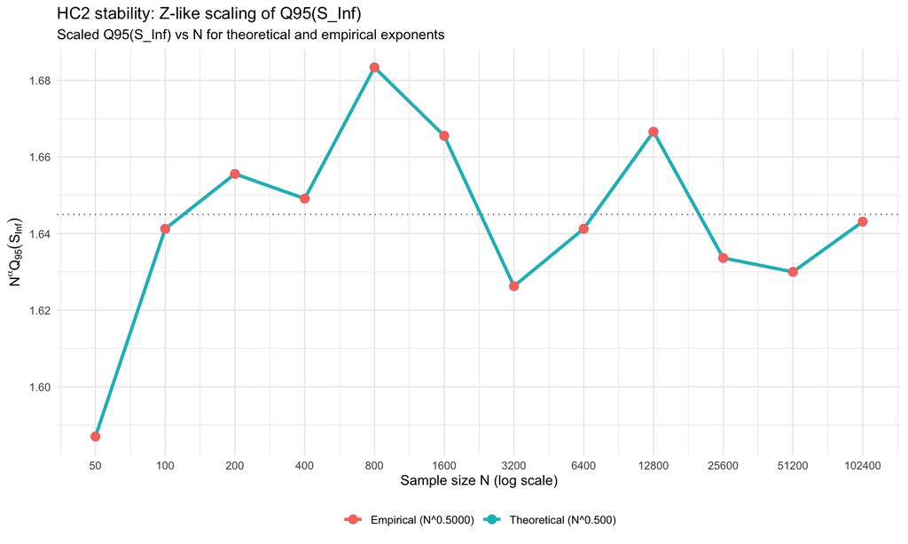

```r
# 5. Stability Plot
plot_dt <- rbind(
  hc2_data[, .(
    N,
    scaled_Q95 = Q95_SR_Inf * (N^EXP_THEORY),
    Type = sprintf("Theoretical (N^%.3f)", EXP_THEORY)
  )],
  hc2_data[, .(
    N,
    scaled_Q95 = Q95_SR_Inf * (N^EXP_EMPIRICAL),
    Type = sprintf("Empirical (N^%.4f)", EXP_EMPIRICAL)
  )]
)

p_z <- ggplot(plot_dt, aes(x = N, y = scaled_Q95, color = Type)) +
  geom_hline(yintercept = z_ref, linetype = "dotted", color = "gray50") +
  geom_line(size = 1.2) +
  geom_point(size = 3) +
  scale_x_log10(breaks = sort(unique(plot_dt$N))) +
  labs(
    title    = "HC2 stability: Z-like scaling of Q95(S_Inf)",
    subtitle = "Scaled Q95(S_Inf) vs N for theoretical and empirical exponents",
    x        = "Sample size N (log scale)",
    y        = expression(N^alpha * Q[95](S[Inf]))
  ) +
  theme_minimal() +
  theme(legend.position = "bottom", legend.title = element_blank())

print(p_z)
```

**Interpretation**: Both the theoretical and empirical approaches agree: the scaled 95th percentile is ~1.645 (standard normal critical value), with tiny uncertainty. This is a remarkable coincidence that makes HC2 easy to use in practice—we can simply use standard statistical cutoffs.

# 8 Section 7: Additional Visualizations

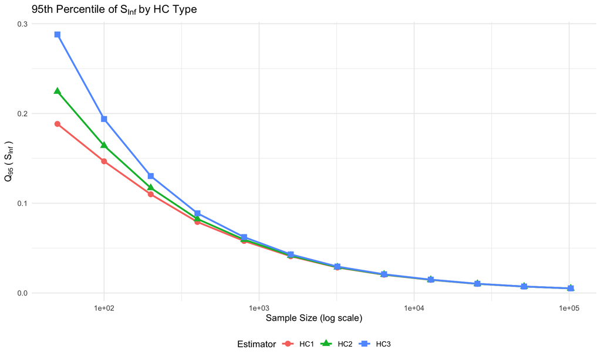

```r
# Plot Q95 trajectories across sample sizes for each HC type
plot_data <- q95_summary

p1 <- ggplot(plot_data, aes(x = N, y = Q95_SR_Inf, color = hc_type, shape = hc_type)) +
  geom_line(size = 1) +
  geom_point(size = 3) +
  scale_x_log10() +
  labs(
    title = expression("95th Percentile of" ~ S[Inf] ~ "by HC Type"),
    x = "Sample Size (log scale)",
    y = expression(Q[95]~"("~S[Inf]~")"),
    color = "Estimator",
    shape = "Estimator"
  ) +
  theme_minimal() +
  theme(legend.position = "bottom")

print(p1)
```

# 9 Summary

This part establishes the homoskedastic benchmark for the inferential score and selects the estimator used in Part 2.

## 9.1 Key Results

1. **HC2 is the most stable estimator**: The upper-tail percentile scales cleanly with $N^{-1/2}$ and shows the smallest variability after scaling.
2. **Calibrated cutoff**: For HC2,
   $$Q_{95}^{(\text{HC2})}(N) \approx
   \frac{1.645}{\sqrt{N}}$$
   The scaled constant matches $z_{0.95}$ within Monte Carlo error, providing a clear decision rule.
3. **Ready for Part 2**: We now have a calibrated reference distribution to evaluate heteroskedasticity severity in realistic data.

## 9.2 Reproducibility Notes

- All random seeds are set in `R/00_config.R` for full reproducibility
- All configuration parameters (sample sizes, simulation counts) are in `R/00_config.R`
- Numerical equivalence to standard R implementations is verified (differences < 1e-10)